# Real Data Analysis for Methylation- EM algorithm

Kushal Kumar Dey

Monday, March 09, 2015

In this script, I perform the EM algorithm type Beta Topic modeling on the the same real data as in the Probe Level analysis- GSE52865 dataset in the GEO Omnibus, which crresponds to the paper **A DNA methylation-based definition of biologically distinct breast cancer subtypes**. We select the $1000$ CpG sites which have the highest coefficient of variation.

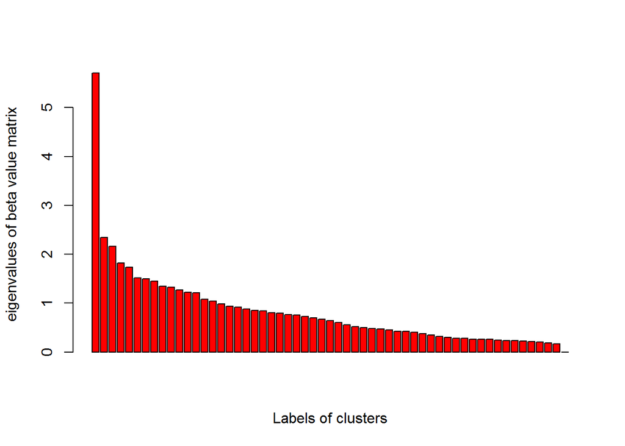

```r
#############  Exploration of the Data for the top 10,000 CpG sites selected using highest CV   #######################################

methData=read.table("D:/Matthew_Stephens_Project/Methylation/Methylation Expt 2/betas_file_10000.txt");
betas=t(methData)

###  now run the remaining part of the Methyl.estimation.R file

###  The number of clusters in the real Data -  by Principal Component Analysis

###  Probably from the PC plots (PC1 vs PC2) or the Circular Projection plot, we

###   can get some intuitive idea


Princomp.analysis=prcomp(betas,center=TRUE);
eigenPrincomp=Princomp.analysis$sdev;
rotPrincomp=Princomp.analysis$rotation;
windows()
barplot(eigenPrincomp,col="red",
    ylab="eigenvalues of beta value matrix",
        xlab="Labels of clusters",xaxt="n");
```

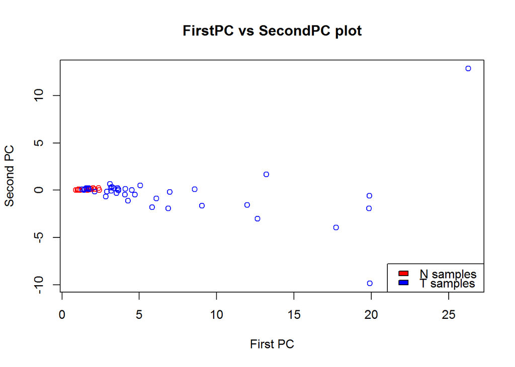

```r
#axis(1,at=0.7+1.2*(0:6),c("PC1","PC2","PC3","PC4","PC5","PC6","PC7"));

projection=t(rotPrincomp[,-dim(rotPrincomp)[2]])%*%t(betas);

windows()
plot(projection[1,],projection[2,],main="FirstPC vs SecondPC plot",xlab="First PC",
    ylab="Second PC",col=c(rep("red",17),rep("blue",40)));
legend("bottomright",c("N samples", "T samples"),fill=c("red","blue"));
```

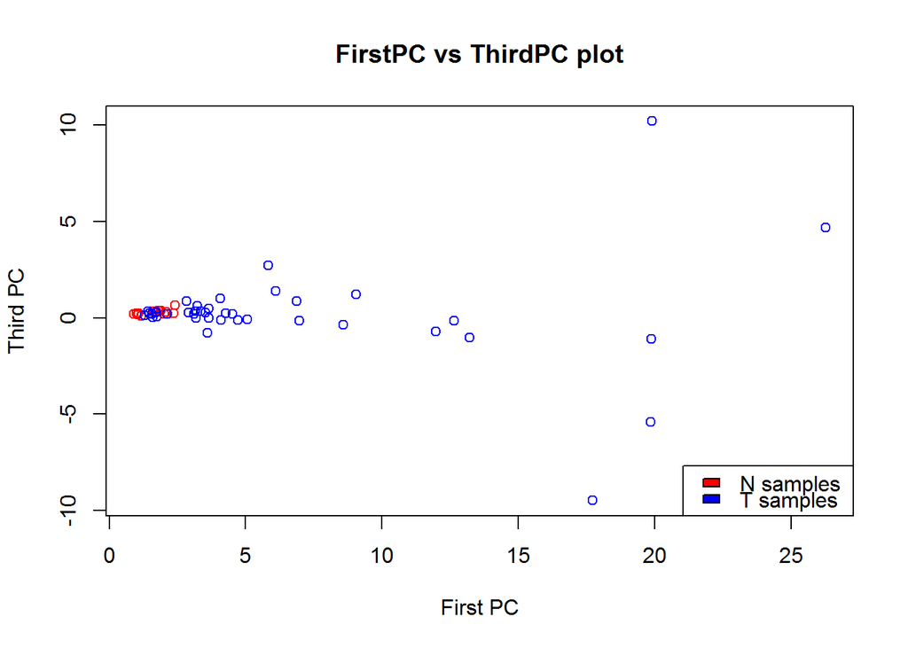

```r
windows()
plot(projection[1,],projection[3,],main="FirstPC vs ThirdPC plot",xlab="First PC",
    ylab="Third PC",col=c(rep("red",17),rep("blue",40)));
legend("bottomright",c("N samples", "T samples"),fill=c("red","blue"));
```

```r
methData_reduced=methData[1:1000,];
```

Now we apply a topic model type approach on the best $1000$ CpG sites. so, we consider $1000 \times 57$ matrix and try to fit a Beta Topic model to that data.

```r
  reverse_transform=function(x)
  {
    out=array(0,K-1);
    for(i in 1:(K-1))
        {
            out[i]=log((x[i]+10^(-5))/(x[K]+10^(-5)));
        }
        return(out)
    }

# Data


    # Log-Likelihood
    loglik_norm <- function(u,y,x) sum((y - x %*% u)^2)

    # Transform the parameters: we just have
    # to find a bijection between R^3
    # and {(a,b,c,d) \in [0,1]^4 : a+b+c+d=1}.

  transform <- function(v)
  {
    # Ensure they in [0,1]
    temp =c(exp(v),1);
    out=temp/(1+sum(exp(v)));
    return(out)
    }
```

Now we consider the **methData_reduced** table that I obtained at the end of the initial R chunk which has $1000$ rows corresponding to the top varying CpG sites and $57$ columns corresponding to the tissue samples of which the first $17$ correspond to the normal tissue samples and the last $40$ corresponds to the tumor tissue samples.

```r
meth=t(methData_reduced);

scale=1; N=dim(meth)[1]; G=dim(meth)[2];

K=6;

####  The starting value of omega (topic prop weights)  ####################

# Use a preset seed so the example is reproducable.
require("setRNG")
old.seed <- setRNG(list(kind="Mersenne-Twister", normal.kind="Inversion",
seed=54321))
library(gtools)
#omega_preprocess=matrix(rdirichlet(N,c(scale/K,scale/K,scale/K,scale/K)), nrow=N);
omega_preprocess=matrix(rdirichlet(N,rep(scale/K,K)), nrow=N);



logit_meth=log(meth+1e-07)-log(1-meth+1e-07);
y=matrix(logit_meth,1,N*G);


omega0=omega_preprocess
alpha0=matrix(rnorm((K)*G,1,1),nrow=(K));
param0=c(matrix(omega0,1,N*K),matrix(alpha0,1,K*G));

library(SQUAREM)

beta_process.probe <- function(param_vec,y)
{
  logit_meth=matrix(y,N,G);
  #N=dim(logit_meth)[1]; G=dim(logit_meth)[2];
  omega0=matrix(param_vec[1:(N*K)],N,K);
    alpha0=matrix(param_vec[-(1:(N*K))],K,G);

    svd_omega=svd(omega0);
    temp1=t(svd_omega$v)%*%diag(1/svd_omega$d^2,dim(omega0)[2])%*%svd_omega$v;
    temp2=t(omega0)%*%logit_meth;
    # temp2=t(omega0)%*%pnorm_meth;
    temp1=solve(t(omega0)%*%omega0);
    H = temp1%*%temp2;

    ###  Estimation of the matrix W (or omega)

    omega=matrix(0,N,K);
    for(n in 1:N)
    {
        omega_vec=omega0[n,];
        meth_vec=logit_meth[n,];
        res=optim(reverse_transform(omega_vec), function(v) loglik_norm(transform(v),meth_vec,t(H)) );
        omega[n,]=transform(res$par);
    }

    param_vec_omega=matrix(omega,1,N*K);
    param_vec_alpha=matrix(H,1,K*G);
    param_new_vec=c(param_vec_omega,param_vec_alpha);
    param_vec=param_new_vec
    return(param_new_vec)
}

options(warn=-1)
system.time(res <- squarem(p=param0,y=y, fixptfn=beta_process.probe, control=list(maxiter = 100, trace = FALSE)));
```

```
##    user  system elapsed
##   45.95    0.03   46.02
```

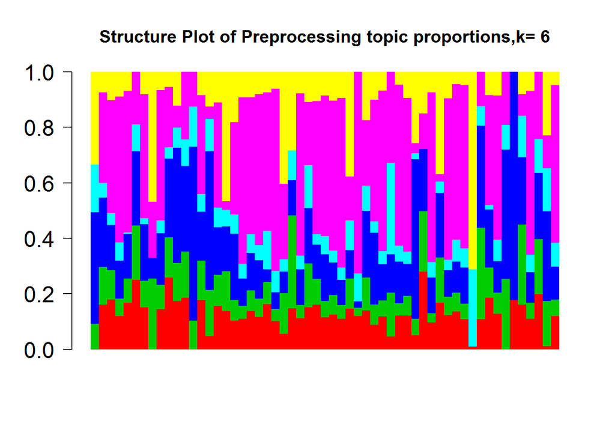

```r
omega_initial=matrix(res$par[1:(N*K)],N,K);
alpha_initial=matrix(res$par[-(1:(N*K))],K,G)

# docweights=omega_initial;
# library(permute);
# library("BioPhysConnectoR");
# perm_set=rbind(1:K,allPerms(1:K));
# diff=array(0,dim(perm_set)[1]);
# for (p in 1:dim(perm_set)[1])
# {
#  temp=docweights[,perm_set[p,]];
#   diff[p]=fnorm(temp,omega_true);
# }

# p_star=which(diff==min(diff));
# docweights=docweights[,perm_set[p_star,]];

# omega_initial=docweights;
# alpha_initial=alpha_initial[perm_set[p_star,],];

windows()
k=K
barplot(t(omega_initial),col=2:(k+1),axisnames=F,space=0,border=NA,main="",las=1,ylim=c(0,1),cex.axis=1.5,cex.main=1.4)
title(main=paste("Structure Plot of Preprocessing topic proportions,k=",K))
```

The effect size estimates could be obtained as follows

```r
################## Final Step  SQUAREM Technique Implementation  ################################################

y=matrix(meth,1,N*G);

scale=1; K=6; N=dim(meth)[1]; G=dim(meth)[2];

phi_true=read.table("D:/Matthew_Stephens_Project/Methylation/Methylation Expt 2/phi_true.txt");
phi_true=as.numeric(as.matrix(phi_true));

####  The starting value of omega (topic prop weights)  ####################

# Use a preset seed so the example is reproducable.
require("setRNG")
old.seed <- setRNG(list(kind="Mersenne-Twister", normal.kind="Inversion",
seed=54321))

omega0=omega_initial;
alpha0=alpha_initial;
param0=c(matrix(omega0,1,N*K),matrix(alpha0,1,K*G));


library(betareg)

beta_final.em <- function(param_vec,y)
{
  meth=matrix(y,N,G);
  omega0=matrix(param_vec[1:(N*K)],N,K);
    alpha0=matrix(param_vec[-(1:(N*K))],K,G);


    ###############   Estimation of omega  ############################

    omega=matrix(0,N,K);
    Z=array(0,c(N,K,G));

    for(n in 1:N)
    {
    temp=meth[n,];
    temp[which(temp<1e-04)]=runif(length(temp<1e-04),0,1e-04);
    meth[n,] = temp;
        for(g in 1:G)
        {
            for(k in 1:K)
            {
                mu=inv.logit(alpha0[k,g]);
                mu[mu<1e-04]=1e-04;
                mu[mu>(1-1e-04)]=(1-1e-04);

                Z[n,k,g]=omega0[n,k]*dbeta(meth[n,g],
                        shape1=mu*phi_true[g],
                        shape2=(1-mu)*phi_true[g],ncp=0);
            }
            Z[n,,g]=(Z[n,,g]+1e-04)/sum(Z[n,,g]+1e-04)
        }
    }

    for(n in 1:N)
    {
        for(k in 1:K)
        {
            omega[n,k]=sum(Z[n,k,])/G;
        }
    }

    ##################  Defining the label matrix ###################

    indicator=matrix(0,N,G);
    for(n in 1:N)
    {
        for(g in 1:G)
        {
            indicator[n,g]=sample(1:K,1,(Z[n,,g]+1e-07)/sum(Z[n,,g]+1e-07),replace=TRUE);
        }
    }


    ##################  Estimation of alpha  ########################

    alpha=alpha0;

  phi=array(0,G)

    for(g in 1:G)
    {
        meth_col=meth[,g];
    meth_col[which(meth_col<1e-03)]=runif(length(meth_col<1e-03),0,1e-03);
    meth[,g]=meth_col;
    indicator_col=indicator[,g];
    if(length(unique(indicator_col))==1)
      fit=betareg(meth_col~1);
    if(length(unique(indicator_col))>1)
          fit=betareg(meth_col~as.factor(indicator_col)-1);
        alpha[sort(unique(indicator_col)),g]=as.numeric(fit$coef[1]$mean);
        phi[g]=as.numeric(fit$coef[2]);
    }

    ################## Pooling everything back in vector ###########

    param_vec_omega=matrix(omega,1,N*K);
    param_vec_alpha=matrix(alpha,1,K*G);
    param_new_vec=c(param_vec_omega,param_vec_alpha);
    param_vec=param_new_vec
    return(param_new_vec)
}


options(warn=-1)
system.time(res <- squarem(p=param0,y=y, fixptfn=beta_final.em, control=list(maxiter = 20, trace = FALSE)));
```

```
##    user  system elapsed
##  938.05    0.08  938.20
```

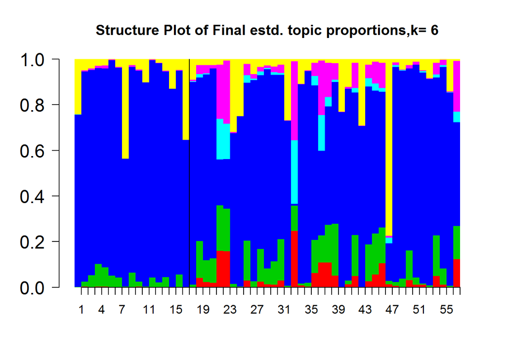

```r
##################  Adjusting for labeling and plotting ####################

omega_final=matrix(res$par[1:(N*K)],N,K);
alpha_final=matrix(res$par[-(1:(N*K))],K,G)



windows()
k=K
barplot(t(omega_final),col=2:(k+1),axisnames=F,space=0,border=NA,main="",las=1,ylim=c(0,1),cex.axis=1.5,cex.main=1.4)
title(main=paste("Structure Plot of Final estd. topic proportions,k=",K))
axis(1,at=1:57,1:57)
abline(v=17)
```

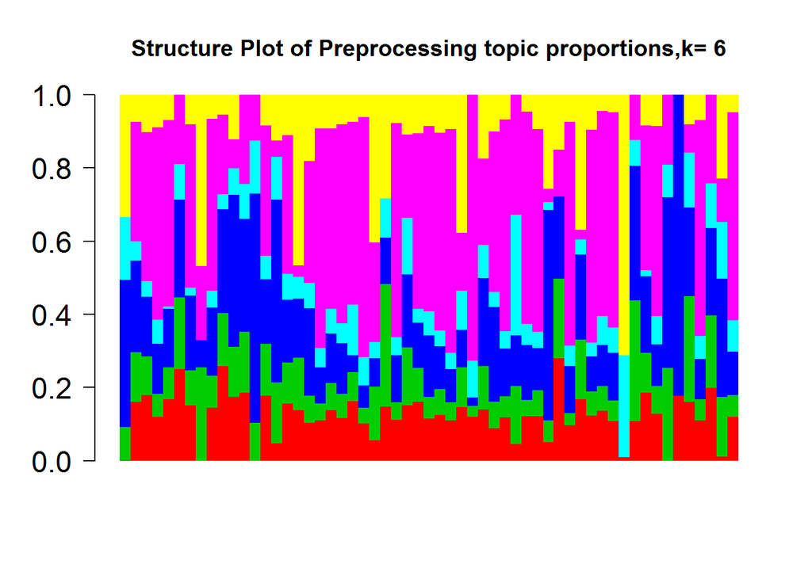

```r
windows()
k=K
barplot(t(omega_initial),col=2:(k+1),axisnames=F,space=0,border=NA,main="",las=1,ylim=c(0,1),cex.axis=1.5,cex.main=1.4)
title(main=paste("Structure Plot of Preprocessing topic proportions,k=",K))
```